## Computer Vision Basics

# Computer Vision Concepts

## Building block of an Image

- The image is made of "pixels"
- Each pixel: small, square, one color
- How many pixels in an image 800 pixel wide, 600 pixels high?  
  just multiply 800 x 600 = 480,000 pixels = 0.48 megapixels
- Typical digital image = 5-20 megapixels
- Each pixel is represent as RGB channel.

## Loading an image

- In python for loading an image use `os.path.join(folder, file_name)`
- Using `imread` in cv2 library you read the image into variable
- Using `imshow` in `matplotlib.pyplot` you show the image

[figure not shown]

```python
## Loading an image
import os
import cv2
import matplotlib.pyplot as plt # (optional) for plotting and showing images inline
IMAGES_FOLDER = os.path.join('./images') # images for visuals
earth_fname = os.path.join(IMAGES_FOLDER,'earth.jpg')
earth_img1 = cv2.imread(earth_fname)
plt.imshow(earth_img1)
```

## Image Shape

- The shape of the image in python is represented as `tupple`
- The `tuple` has dimenstion of the image as (Row, Column, colour channel)
- This means there as two dimensional array of #row, #column and at each cell of array there is an array of three values representing the amout of Red, Blue and Green

```python
# Shape of the array
earth_img1.shape

# RGB values at cell [0,0]

earth_img1[0][0]
```

```
array([51, 33, 26], dtype=uint8)
```

## Changing Colorspaces

- to convert images from one color-space to another, like BGR ↔ Gray, BGR ↔ HSV etc.
- cv2.cvtColor(), cv2.inRange()
- For color conversion, we use the function cv2.cvtColor( name_input_image, flag ) where flag determines the type of conversion.

[figure not shown]

```python
# ColorSpace Conversion : see the colour difference
earth_img2 = cv2.cvtColor(earth_img1, cv2.COLOR_BGR2RGB)
plt.imshow(earth_img2)
```

## Image Filters and Functions

- Many times, images contain complex information that isn't need for a computation or reduces the speed of computation without much value added.
- Gaussian Filtering In this approach, instead of a box filter consisting of equal filter coefficients, a Gaussian kernel is used.
- It is done with the function, `cv2.GaussianBlur()`. We should specify the width and height of the kernel which should be positive and odd.
- An image kernel is a small matrix used to apply effects like the ones you might find in Photoshop or Gimp, such as blurring, sharpening, outlining or embossing.

[figure not shown]

```python
blur_img = earth_img2.copy()
blur_img = cv2.GaussianBlur(blur_img, (41, 41),10)
plt.imshow(blur_img)
```

## Seprate the each plane of the color image

- We know that color image is combination of 3-planes Red, Green and Blue. we can seprate the each plane to extract some information.
- To do that we need to set 0 value to the RGB channel in a loop

```
(480, 852, 3)
```

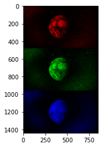

```python
# Show Red/Green/Blue
import numpy as np
images = []
print(earth_img2.shape)
for i in [0, 1, 2]:
    colour = earth_img2.copy()
    if i != 0: colour[:,:,0] = 0
    if i != 1: colour[:,:,1] = 0
    if i != 2: colour[:,:,2] = 0
    images.append(colour)

plt.imshow(np.vstack(images))
```

## Image crop

If we need to crop specific portion of the image, for that it requires x and y coordinates of that portion.

[figure not shown]

```python
image_cropped = earth_img2[100:380, 280:500]
plt.imshow(image_cropped)
```

## Dilating (Morphological Transformations)

Dilation, as it sounds, dilates pixel neighbourhoods by finding maximums over the image by the kernel size given. This is useful for expanding selections

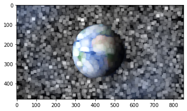

```python
dilate_img = earth_img2.copy()
dilate_img = cv2.dilate(dilate_img, np.ones((15,15), dtype=np.uint8), iterations=1)
plt.imshow(dilate_img)
```

## Erosion

Erosion is the opposite of dilation, useful for remove noise. The basic idea of erosion is just like soil erosion only, it erodes away the boundaries of foreground object.

- It computes a local minimum over the area of given kernel.
- As the kernel is scanned over the image, we compute the minimal pixel value overlapped by kernal and replace the image pixel under the anchor point with that minimal value.
- all the pixels near boundary will be discarded depending upon the size of kernel. So the thickness or size of the foreground object decreases or simply white region decreases in the image.

[figure not shown]

```python
import numpy as np
erosion_img = earth_img2.copy()
kernel = np.ones((10,10),np.uint8)
erosion_img = cv2.erode(erosion_img, kernel, iterations=1)
plt.imshow(erosion_img)
```

## Image Edge Detection Gradients

- Find Image gradients,edges. There are different edge detectors like Sobel, Prewitt, Laplacian, Canny, etc.
- Canny Edge Detection is a popular edge detection algorithm. It was developed by John F. Canny in 1986.
- cv2.getTrackbarPos(), cv2.createTrackbar() can be used to create simple application which shows the color you specify. You have a window which shows the color and three trackbars to specify each of B,G,R colors. You slide the trackbar and correspondingly window color changes

[figure not shown]

```python
import numpy as np
canny_img = earth_img2.copy()
kernel = np.ones((8,8), np.uint8)
canny_img = cv2.erode(canny_img, kernel, iterations=1)
edges = cv2.Canny(canny_img,100,100)
plt.imshow(edges.astype(np.uint8), cmap='gray')
```

[figure not shown]

## Thresholding

Thresholding can be thought of as a function applied to each pixel of an image. This function takes a min and max thresholding values and if the pixel value falls in this range, it will 'return' the pixel, if not it will 'return' a black pixel.

Generally, thresholding is applied to a greyscale image, but may also be applied to colour images, following a similair principle.

```
(480, 852)
```

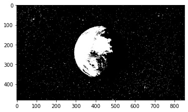

```python
thresh_img = earth_img2.copy()
thresh_img = cv2.cvtColor(thresh_img, cv2.COLOR_BGR2GRAY)
ret, thresh = cv2.threshold(thresh_img, 80, 255, cv2.THRESH_BINARY)
plt.imshow(thresh, cmap='gray')
print(thresh.shape)
```

## Other Techniques

- Background substraction: Using a background image to find differences (can be used for images and video)
- Contours: contours is done by finding points or corners in an image and connecting those that have the same color or intensity.
- Tracking: OpenCV's tracking algorithms help to track objects. MIL, BOOSTING, MEDIANFLOW,TLD, KCF are tracking algorithms